# EDA-challenge

Matt Ming

2/7/2022

# Preliminaries

First, to get the packages needed for this assignment:

```r
library(tidyverse)
library(dplyr)
```

Next, to load in the data from the url provided in the assignment:

```r
f <- "https://raw.githubusercontent.com/difiore/ada-2022-datasets/main/data-wrangling.csv"
d <- read_csv(f, col_names = TRUE)
names(d)
```

```
##  [1] "Scientific_Name"         "Family"
##  [3] "Genus"                   "Species"
##  [5] "Brain_Size_Species_Mean" "Body_mass_male_mean"
##  [7] "Body_mass_female_mean"   "MeanGroupSize"
##  [9] "AdultMales"              "AdultFemale"
## [11] "GR_MidRangeLat_dd"       "Precip_Mean_mm"
## [13] "Temp_Mean_degC"          "HomeRange_km2"
## [15] "DayLength_km"            "Fruit"
## [17] "Leaves"                  "Fauna"
## [19] "Canine_Dimorphism"       "Feed"
## [21] "Move"                    "Rest"
## [23] "Social"
```

# Assignment

## 1 - 3

Now, we will create some new variables:

BSD (Body Size Dimorphism) = Ratio of avg male mass (“Body_mass_male_mean”) to avg female mass (“Body_mass_female_mean”)

```r
d$BSD <- d$Body_mass_male_mean/d$Body_mass_female_mean
d$sex_ratio <- d$AdultFemale/d$AdultMales
d$DI <- d$DayLength_km/(sqrt(d$HomeRange_km2/pi))
```

## 4

Generating and analyzing plots for Day Range Length (“DayLength_km”) vs Time Moving (“Move”):

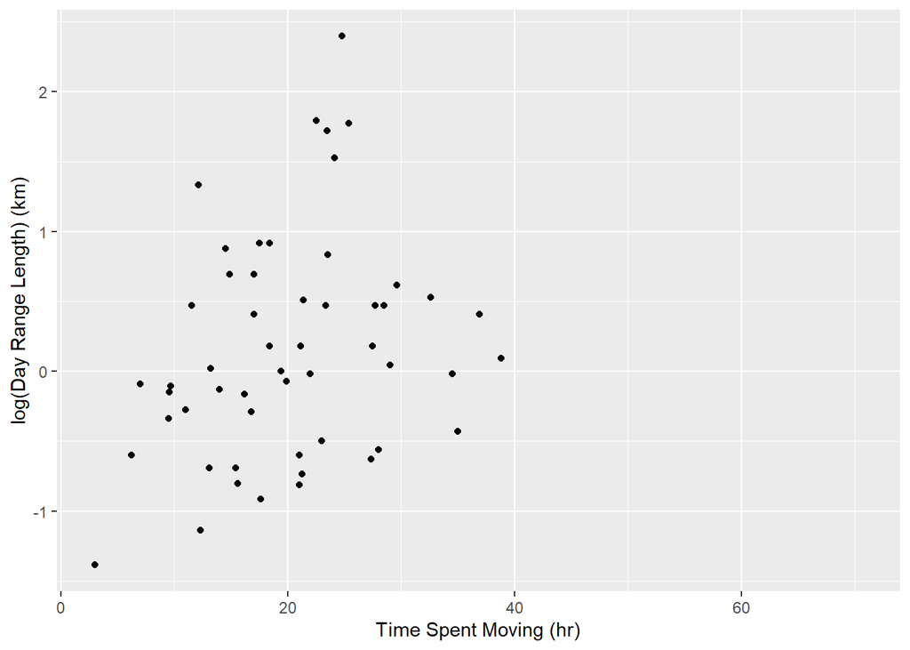

```r
p1 <- ggplot(d,aes(x = Move,y = log(DayLength_km))) +
  ylab("log(Day Range Length) (km)") + xlab("Time Spent Moving (hr)") +
  geom_point(na.rm = TRUE)
p1
```

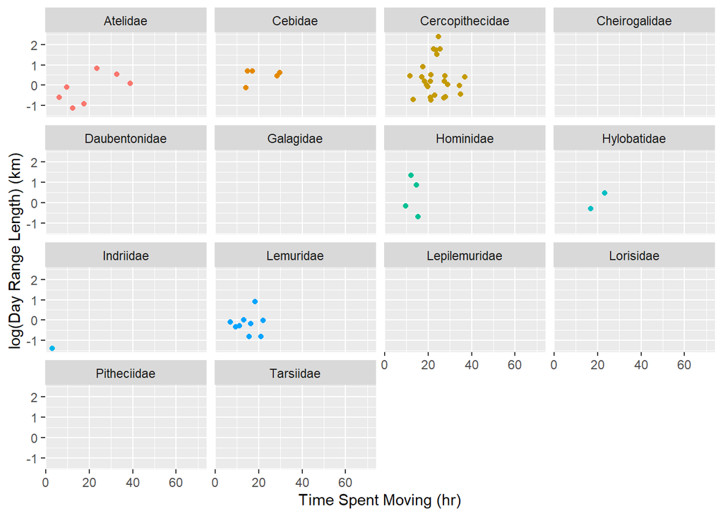

```r
p1 <- p1 + aes(color = factor(Family)) + facet_wrap(~Family,ncol = 4) +
  theme(legend.position = "none")
p1
```

Based on the plot above, there seems to be a loose positive correlation between time spent moving and distance traveled. This correlation is recapitulated in the Atelidae Hylobatidae families, and weakly in the Cercopithecidae family, but this trend does not appear to hold with the other families for which there is data. Because of the range of values in Range Length, this field was transformed to a log scale for more consistent grouping of points.

## 5

Generating and analyzing plots for Day Range Length (“DayLength_km”) vs Group Size (“MeanGroupSize”):

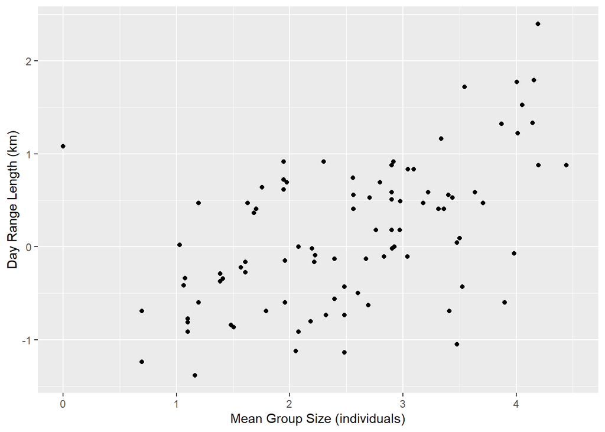

```r
p2 <- ggplot(d,aes(x = log(MeanGroupSize),y = log(DayLength_km))) +
  ylab("Day Range Length (km)") + xlab("Mean Group Size (individuals)") +
  geom_point(na.rm = TRUE)
p2
```

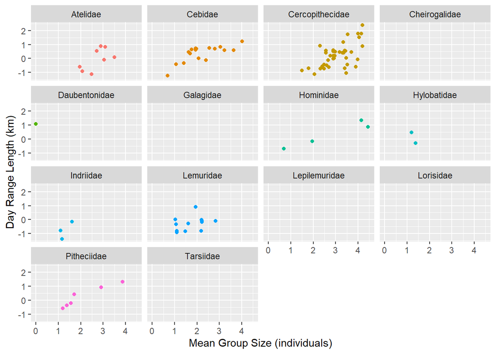

```r
p2 <- p2 + aes(color = factor(Family)) + facet_wrap(~Family,ncol = 4) +
  theme(legend.position = "none")
p2
```

Based on the plot above, there seems to be a loose positive correlation between species average group size and distance traveled. This correlation is more strongly seen in family-level data, specifically for the Atelidae, Cebidae, Cercopithecidae, Hominidae, Indriidae, and Pitheciidae families; the Lemuridae family showed not much of a correlation between these variables, while Hylobatidae actually showed a negative correlation. Because of the range of values in both Range Length and Mean Group Size, both of these fields were transformed to a log scale for more consistent grouping of points.

## 6

Generating and analyzing plots for Body Size Dimorphism (“BSD”) vs Canine Size Dimorphism (“Canine_Dimorphism”):

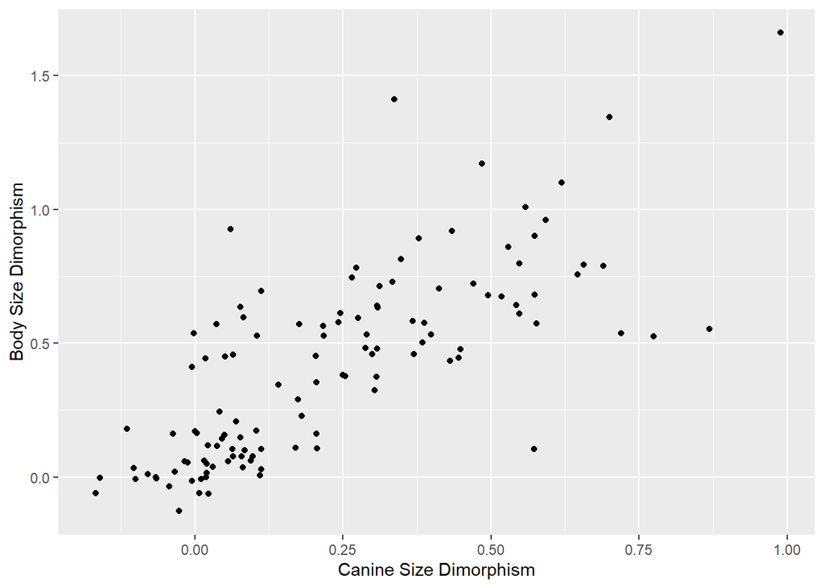

```r
p3 <- ggplot(d,aes(x = log(BSD),y = log(Canine_Dimorphism))) +
  ylab("Body Size Dimorphism") + xlab("Canine Size Dimorphism") +
  geom_point(na.rm = TRUE)
p3
```

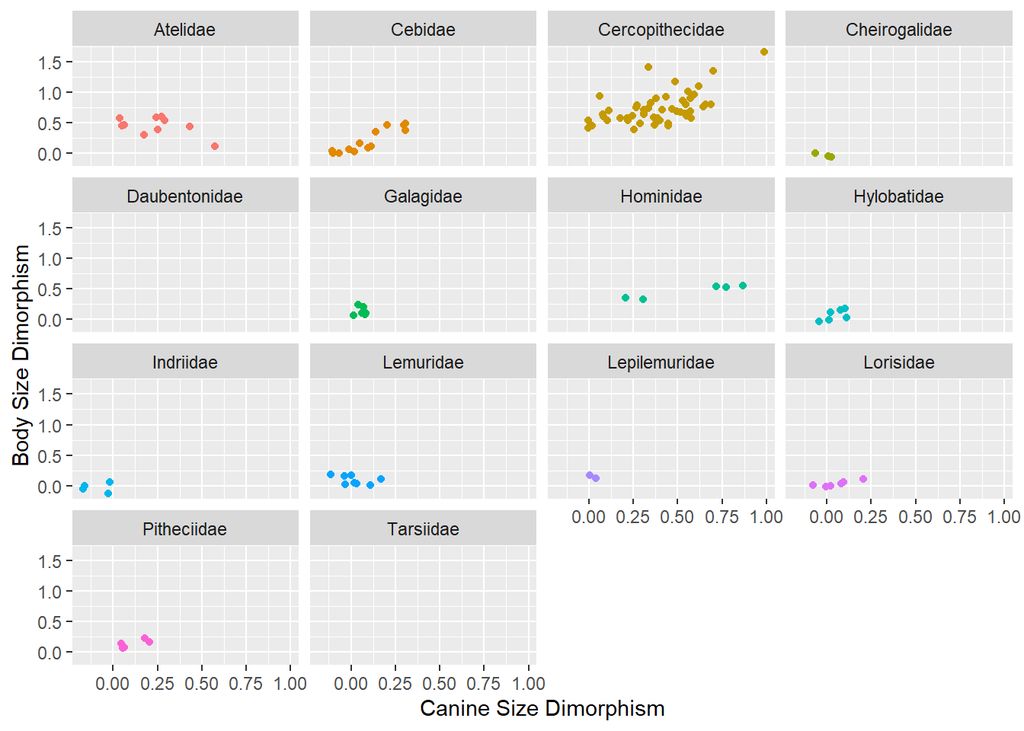

```r
p3 <- p3 + aes(color = factor(Family)) + facet_wrap(~Family,ncol = 4) +
  theme(legend.position = "none")
p3
```

Based on the plot above, there seems to be a loose positive correlation between Body Size Dimorphism and Canine Size Dimorphism. Interestingly, this pattern is not really seen very strongly on an Individual family basis, except in Cebidae; there is also a slight positive correlation in Cercopithecidae, Galagidae, Hominidae, Hylobatidae, Lorisidae, and Pitheciidae.

## 7

Create a new variable called diet_strategy which has labels

-“frugivore” if fruits make up more than 50% of diet

-“folivore” if leaves make up more than 50% of diet

-“omnivore” if neither of the above is true

```r
d <- mutate(d, "diet_strategy" = ifelse(
  d$Fruit >= 50,"frugivore",
  ifelse(as.numeric(d$Leaves) >= 50,"folivore","omnivore")
))
```

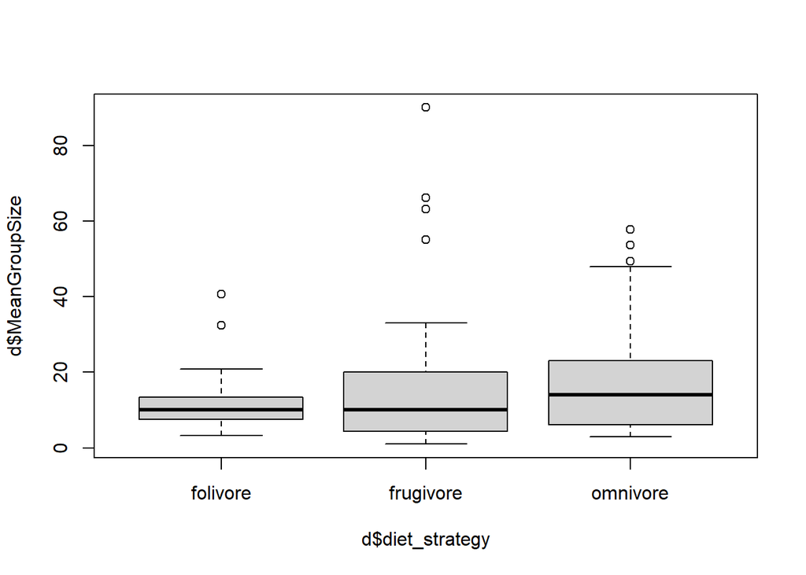

```r
boxplot(d$MeanGroupSize~d$diet_strategy)
```

Based on the above boxplot, it seems that the average group size of frugivores is no bigger than the average group size of folivores, but the largest frugivore groups are larger than the largest folivore groups.

## 8

Now, adding a variable “Binomial” to the dataframe d, which is a concatenation of Genus (“Genus”) and Species (“Species”)

Trimming the dataframe to only include the variables “Binomial”, “Family”, “Brain_size_species_mean”, and “Body_mass_male_mean”

Grouping the variables by “Family”

Calculating the average Brain Size and Male Body Mass per Family

Finally, arranging by increasing brain size

```r
d %>% mutate(Binomial = paste(d$Genus,d$Species)) %>%
  select(Binomial,Family,Brain_Size_Species_Mean,Body_mass_male_mean) %>%
  group_by(Family) %>% summarise(
    Brain_size_species_mean = mean(Brain_Size_Species_Mean,na.rm = TRUE),
    Body_mass_male_mean = mean(Body_mass_male_mean,na.rm = TRUE)) %>%
  arrange(Brain_size_species_mean)
```

```
## # A tibble: 14 x 3
##    Family          Brain_size_species_mean Body_mass_male_mean
##    <chr>                             <dbl>               <dbl>
##  1 Tarsiidae                          3.26                131
##  2 Cheirogalidae                      4.04                193.
##  3 Galagidae                          5.96                395.
##  4 Lepilemuridae                      7.27                792
##  5 Lorisidae                          8.67                512.
##  6 Lemuridae                         23.1                2077.
##  7 Cebidae                           23.9                1012.
##  8 Indriidae                         27.3                3638.
##  9 Daubentonidae                     44.8                2620
## 10 Pitheciidae                       56.3                1955.
## 11 Atelidae                          80.6                7895.
## 12 Cercopithecidae                   85.4                9543.
## 13 Hylobatidae                      101.                 6926.
## 14 Hominidae                        410.                98681.
```